# Project Steps

Parth Patel and Ana Phan

Sunday, March 01, 2015

### Importing the Dataframe

##### First, import the .csv file into SQL.

Click the (+) to access the dropdown file system of the connection in which you would like to import the data.Right click the **Tables** folder and select the **Import Data** selection.

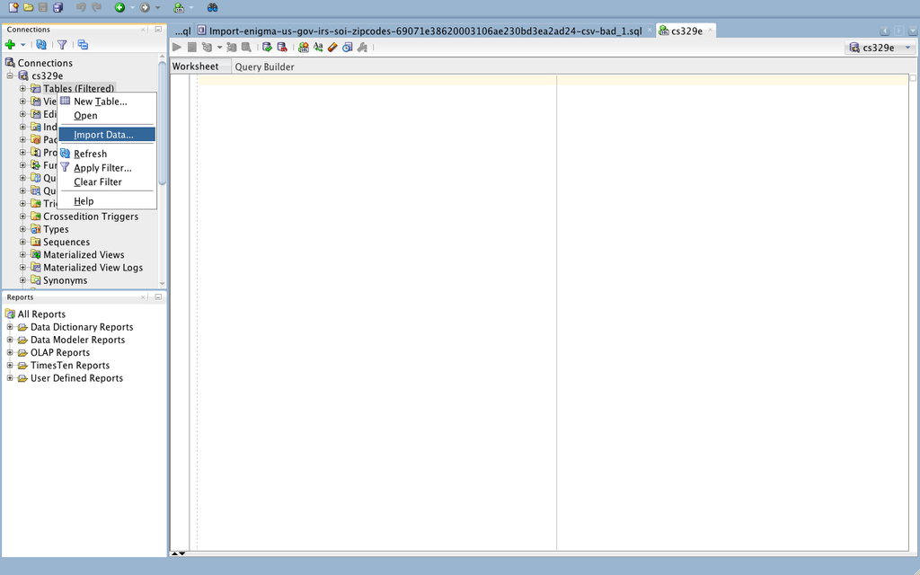

Find the .csv file you want to work with and select it for import.

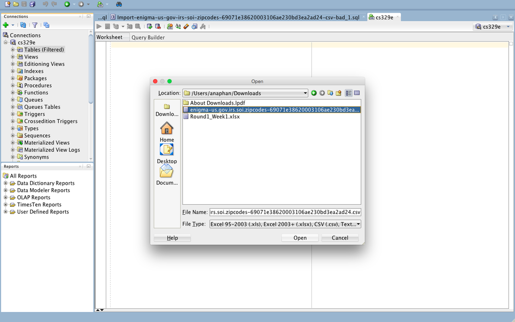

Run through the Data Import Wizard, giving the table a name and identifying the types that each column represent.

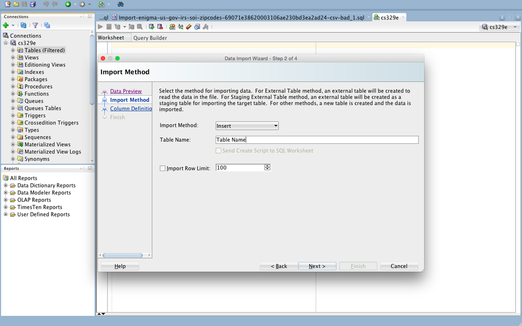

Once you are finished with this, the data has been stored in the database.

In our particular case, the data has been stored on a cloud-based database. An SQL query will be used to extract the dataframe from the database for access during the project. The following example query was used:

```
df <- data.frame(fromJSON(getURL(URLencode('129.152.144.84:5001/rest/native/?query="select * from DATAFRAME"'),httpheader=c(DB='jdbc:oracle:thin:@129.152.144.84:1521:ORCL', USER='C##cs329e_UTEid', PASS='orcl_UTEid', MODE='native_mode', MODEL='model', returnDimensions = 'False', returnFor = 'JSONLITE'), verbose = TRUE)))
```

## Datasets

### Distribution of Undergraduate Majors

This dataset presents the first major of degree achieved by people that are 25 years and older. Data is distributed according to geographical ID. This ID information is translated in a later table.

```r
source("../01 Data/Majors dataset.R")
tbl_df(mdf)
```

```
## Source: local data frame [7,234 x 17]
##
##             GEOID TOTAL COMPUTERS_MATH_STATS BIOLOGY_AND_AGRICULTURE
## 1  79500US0602601 15383                  362                    1227
## 2  79500US0602602 13682                  386                    1426
## 3  79500US0602705 19387                 1834                     968
## 4  79500US0602709 22467                 2016                     639
## 5  79500US0602710 37408                 2610                    2266
## 6  79500US0602711 28262                 1794                    1681
## 7  79500US0602714  8303                  326                     794
## 8  79500US0602900  9185                  160                     643
## 9  79500US0603002 18267                  434                    1127
## 10 79500US0603402 42249                  432                    4844
## ..            ...   ...                  ...                     ...
## Variables not shown: PHYSICS (int), PSYCHOLOGY (int), SOCIOLOGY (int),
##   ENGINEERING (int), MULTIDISCIPLINARY_STUDIES (int), SCIENCES (int),
##   BUSINESS (int), EDUCATION (int), LITERATURE_AND_LANGUAGES (int),
##   LIBERAL_ARTS_AND_HISTORY (int), VISUAL_AND_PERFORMING_ARTS (int),
##   COMMUNICATION (int), OTHER (int)
```

### Geographical ID with States

This dataset presents the geographical ID and correlates it to the state in which that ID is.

```r
source("../01 Data/States dataset.R")
tbl_df(sdf)
```

```
## Source: local data frame [7,235 x 4]
##
##                X1    X2                                                 X3
## 1   GEOGRAPHIC_ID STATE                                         PLACE_NAME
## 2  97000US0609640    CA  Conejo Valley Unified School District, California
## 3  97000US0609850    CA   Corona-Norco Unified School District, California
## 4  97000US0610620    CA    Davis Joint Unified School District, California
## 5  97000US0612330    CA      Elk Grove Unified School District, California
## 6  97000US0613890    CA Folsom-Cordova Unified School District, California
## 7  97000US0616740    CA        Hayward Unified School District, California
## 8  97000US0622500    CA     Long Beach Unified School District, California
## 9  97000US0622710    CA    Los Angeles Unified School District, California
## 10 97000US0623610    CA        Manteca Unified School District, California
## ..            ...   ...                                                ...
## Variables not shown: X4 (fctr)
```

### Average Income of States

This dataset presents the average and median income of each state.

```r
source("../01 Data/Income dataset.R")
tbl_df(idf)
```

```
## Source: local data frame [54 x 5]
##
##    ST                STATE  TOT_EMP A_MEAN A_MEDIAN
## 1  AL              Alabama  1844080  40240    30390
## 2  AK               Alaska   322660  53110    44350
## 3  AZ              Arizona  2475660  44370    34170
## 4  AR             Arkansas  1152600  37340    28910
## 5  CA           California 14714530  53030    38920
## 6  CO             Colorado  2295000  48950    37530
## 7  CT          Connecticut  1635590  54410    42280
## 8  DE             Delaware   412140  49260    37320
## 9  DC District of Columbia   665850  77040    63680
## 10 FL              Florida  7453230  41140    30660
## .. ..                  ...      ...    ...      ...
```

## Dataframes

### Dataframe 1: Inner Join of the Majors and States

The two datasets of undergraduate majors and states are joined in SQL by using the geographical ID column. The resulting dataset gives the percentages of each major for every state in the U.S.

```r
source("../01 Data/Majors Percentage INNER JOINED dataset.R")
tbl_df(mjdf)
```

```
## Source: local data frame [7,234 x 16]
##
##    STATE COMPUTERS.MATH.AND.STATS BIOLOGY.AND.AGRICULTURE  PHYSICS
## 1     CA                 2.353247                7.976337 2.704284
## 2     CA                 2.821225               10.422453 1.410612
## 3     CA                 9.459948                4.993037 4.023314
## 4     CA                 8.973161                2.844172 3.912405
## 5     CA                 6.977117                6.057528 1.652053
## 6     CA                 6.347746                5.947916 3.149105
## 7     CA                 3.926292                9.562809 1.939058
## 8     CA                 1.741971                7.000545 2.362548
## 9     CA                 2.375869                6.169595 1.516396
## 10    CA                 1.022509               11.465360 1.618973
## ..   ...                      ...                     ...      ...
## Variables not shown: PSYCHOLOGY (dbl), SOCIOLOGY (dbl), ENGINEERING (dbl),
##   MULTIDISCIPLINARY.STUDIES (dbl), SCIENCES (dbl), BUSINESS (dbl),
##   EDUCATION (dbl), LITERATURE.AND.LANGUAGES (dbl),
##   LIBERAL.ARTS.AND.HISTORY (dbl), VISUAL.AND.PERFORMING.ARTS (dbl),
##   COMMUNICATION (dbl), OTHER (dbl)
```

### Dataframe 2: Left Join of Income and Graduates

A Graduate table was constructed in SQL prior to this join. Then a second SQL query was run to join the Graduates table to the Income table through state to represent the total graduates and annual income for each state.

```r
source("../01 Data/Graduates OUTER JOINED dataset.R")
tbl_df(sigdf)
```

```
## Source: local data frame [7,234 x 3]
##
##    State Total.Graduates Average.Income
## 1     CA           15383          53030
## 2     CA           13682          53030
## 3     CA           19387          53030
## 4     CA           22467          53030
## 5     CA           37408          53030
## 6     CA           28262          53030
## 7     CA            8303          53030
## 8     CA            9185          53030
## 9     CA           18267          53030
## 10    CA           42249          53030
## ..   ...             ...            ...
```

### Dataframe 3: Right Join of Majors and States

The majors and states datasets are joined using geogrphical ID again but gives total graduates instead of percentages.

```r
source("../01 Data/Majors Totals RIGHT JOINED dataset.R")
tbl_df(ddf)
```

```
## Source: local data frame [7,234 x 16]
##
##    STATE COMPUTERS.MATH.AND.STATS BIOLOGY.AND.AGRICULTURE PHYSICS
## 1     CA                      362                    1227     416
## 2     CA                      386                    1426     193
## 3     CA                     1834                     968     780
## 4     CA                     2016                     639     879
## 5     CA                     2610                    2266     618
## 6     CA                     1794                    1681     890
## 7     CA                      326                     794     161
## 8     CA                      160                     643     217
## 9     CA                      434                    1127     277
## 10    CA                      432                    4844     684
## ..   ...                      ...                     ...     ...
## Variables not shown: PSYCHOLOGY (int), SOCIOLOGY (int), ENGINEERING (int),
##   MULTIDISCIPLINARY.STUDIES (int), SCIENCES (int), BUSINESS (int),
##   EDUCATION (int), LITERATURE.AND.LANGUAGES (int),
##   LIBERAL.ARTS.AND.HISTORY (int), VISUAL.AND.PERFORMING.ARTS (int),
##   COMMUNICATION (int), OTHER (int)
```

## Data Wrangling

Three data wrangling sets were constructed using %>% on the joined datasets.

### Distribution of Degrees for Each State

First, dataframe 1 is piped through a group by statement to sort by state followed by a summarization to generate a single mean value for each degree. The number is normalized to a percentage so that each state had a distribution of degrees. The data was then reformatted to fit the “tidy” specifications. To generate a single png for all the states, a for loop was utilized in conjunction with the png function through a list to populate a single png.

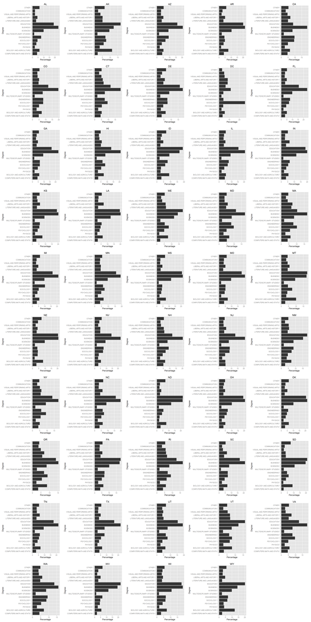

Based on the data, education and business first bachelor degrees are prominent in a majority of the states and that states have a varying distribution of degrees based on its society and employment. In the case of DC, the higher percentage of sociology degrees have a correlation with the greater amount of politicians concentrated in the area.

### Average Income vs Total Graduates by State

Next, dataframe 2 is grouped by state and subsequently summarised to generate the total amount of graduates and average income for each state. The dataframe is then run through ggplot to generate a scatterplot that is color coded by state.

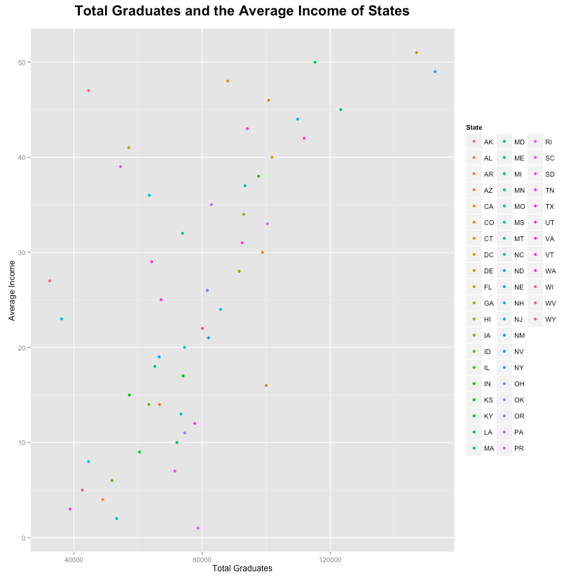

From this scatterplot, a direct linear relationship can be seen between number of graduates and average income. As the total number of graduates with bachelor’s degrees increases, there is a similar increase in the average income.

### Total Graduate Distribution by State of Degrees

Finally, dataframe 3 is piped through a group by statement to sort by state followed by a summarization to generate a single total value for each degree. The data was then reformatted to fit the “tidy” specifications. To generate a single png for all the degrees, a for loop was utilized in conjunction with the png function through a list to populate a single png.

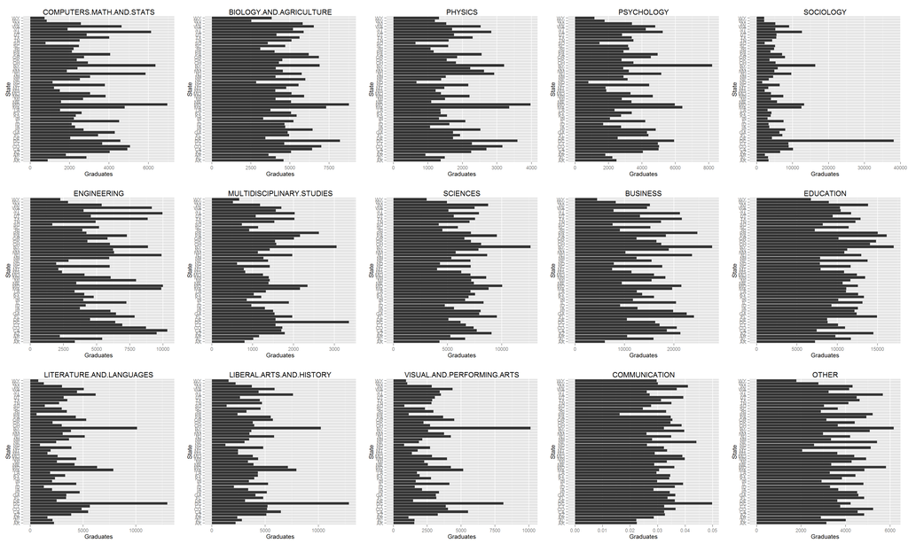

Similar to the first data wrangle, this visualization shows instead, the total graduates rather than a percentage of each degree in every state. For each degree, we can see the distribution of that degree across all states.